# STAT656projectKM

Ken Marciel

11/13/2020

## COVID-19 and Unemployment in the United States

# Data preprocessing step 1: U.S. COVID-19 aggregate data

```r
# read in data
covid19 = read.csv('C:\\Users\\keoka\\OneDrive - Texas A&M University\\Courses\\STAT_656\\Project\\Data\\CDC\\United_States_COVID-19_Cases_and_Deaths_by_State_over_Time.csv')

# sort rows alphabetically by state
covid19 = covid19[order(covid19$state),]

# subset columns
covid19 = covid19[,c(1,2,3,6,8,11)]

# subset rows
remObs  = c("AS", "FSM","GU","MP","NYC","PR","PW","RMI","VI")
covid19 = covid19[!covid19$state %in% remObs,]
covid19 = covid19[covid19$submission_date > "01/31/2020",]
unique(covid19[,2]) # state should have 51 values
```

```
##  [1] "AK" "AL" "AR" "AZ" "CA" "CO" "CT" "DC" "DE" "FL" "GA" "HI" "IA" "ID" "IL"
## [16] "IN" "KS" "KY" "LA" "MA" "MD" "ME" "MI" "MN" "MO" "MS" "MT" "NC" "ND" "NE"
## [31] "NH" "NJ" "NM" "NV" "NY" "OH" "OK" "OR" "PA" "RI" "SC" "SD" "TN" "TX" "UT"
## [46] "VA" "VT" "WA" "WI" "WV" "WY"
```

# Data preprocessing step 2: U.S. COVID-19 monthly data

```r
# monthly totals

covidJan    = covid19[covid19$submission_date > "12/31/2019" &
                        covid19$submission_date < "02/01/2020",]
newCaseJan  = sum(covidJan[,4])
totCaseJan  = newCaseJan
newDeathJan = sum(covidJan[,6])
totDeathJan = newDeathJan

covidFeb    = covid19[covid19$submission_date > "01/31/2020" &
                        covid19$submission_date < "03/01/2020",]
newCaseFeb  = sum(covidFeb[,4])
totCaseFeb  = sum(newCaseFeb, totCaseJan)
newDeathFeb = sum(covidFeb[,6])
totDeathFeb = sum(newDeathFeb, totDeathJan)

covidMar    = covid19[covid19$submission_date > "02/29/2020" &
                        covid19$submission_date < "04/01/2020",]
newCaseMar  = sum(covidMar[,4])
totCaseMar  = sum(newCaseMar, totCaseFeb)
newDeathMar = sum(covidMar[,6])
totDeathMar = sum(newDeathMar, totDeathFeb)

covidApr    = covid19[covid19$submission_date > "03/31/2020" &
                        covid19$submission_date < "05/01/2020",]
newCaseApr  = sum(covidApr[,4])
totCaseApr  = sum(newCaseApr, totCaseMar)
newDeathApr = sum(covidApr[,6])
totDeathApr = sum(newDeathApr, totDeathMar)

covidMay    = covid19[covid19$submission_date > "04/30/2020" &
                        covid19$submission_date < "06/01/2020",]
newCaseMay  = sum(covidMay[,4])
totCaseMay  = sum(newCaseMay, totCaseApr)
newDeathMay = sum(covidMay[,6])
totDeathMay = sum(newDeathMay, totDeathApr)

covidJun    = covid19[covid19$submission_date > "05/31/2020" &
                        covid19$submission_date < "07/01/2020",]
newCaseJun  = sum(covidJun[,4])
totCaseJun  = sum(newCaseJun, totCaseMay)
newDeathJun = sum(covidJun[,6])
totDeathJun = sum(newDeathJun, totDeathMay)

covidJul    = covid19[covid19$submission_date > "06/30/2020" &
                        covid19$submission_date < "08/01/2020",]
newCaseJul  = sum(covidJul[,4])
totCaseJul  = sum(newCaseJul, totCaseJun)
newDeathJul = sum(covidJul[,6])
totDeathJul = sum(newDeathJul, totDeathJun)

covidAug    = covid19[covid19$submission_date > "07/31/2020" &
                        covid19$submission_date < "09/01/2020",]
newCaseAug  = sum(covidAug[,4])
totCaseAug  = sum(newCaseAug, totCaseJul)
newDeathAug = sum(covidAug[,6])
totDeathAug = sum(newDeathAug, totDeathJul)

covidSep    = covid19[covid19$submission_date > "08/31/2020" &
                        covid19$submission_date < "10/01/2020",]
newCaseSep  = sum(covidSep[,4])
totCaseSep  = sum(newCaseSep, totCaseAug)
newDeathSep = sum(covidSep[,6])
totDeathSep = sum(newDeathSep, totDeathAug)

covidOct    = covid19[covid19$submission_date > "09/30/2020" &
                        covid19$submission_date < "11/01/2020",]
newCaseOct  = sum(covidOct[,4])
totCaseOct  = sum(newCaseOct, totCaseSep)
newDeathOct = sum(covidOct[,6])
totDeathOct = sum(newDeathOct, totDeathSep)

newCase     = c(newCaseFeb, newCaseMar, newCaseApr, newCaseMay,
                newCaseJun, newCaseJul, newCaseAug, newCaseSep,
                newCaseOct)

totCase     = c(totCaseFeb, totCaseMar, totCaseApr, totCaseMay,
                totCaseJun, totCaseJul, totCaseAug, totCaseSep,
                totCaseOct)

newDeath    = c(newDeathFeb, newDeathMar, newDeathApr, newDeathMay,
                newDeathJun, newDeathJul, newDeathAug, newDeathSep,
                newDeathOct)

totDeath    = c(totDeathFeb, totDeathMar, totDeathApr, totDeathMay,
                totDeathJun, totDeathJul, totDeathAug, totDeathSep,
                totDeathOct)

month       = 1:9

covidMonthly  = cbind(month, newCase, totCase, newDeath, totDeath)
```

# Data preprocessing step 3: U.S. unemployment monthly data

```r
uRate = read.csv('C:\\Users\\keoka\\OneDrive - Texas A&M University\\Courses\\STAT_656\\Project\\Data\\BLS\\Unemployment Rate\\Table Format\\HTML table\\Unemployment Rate\\SeriesReport-20201113192516_d8b631.csv')
uRate = as.numeric(t(uRate[84,3:11]))
#colnames(uRate) = 'uRate'
```

# Data preprocessing step 4: U.S. monthly COVID-19 and unemployment

```r
# Combined data set
covidUnemployment  = data.frame(cbind(uRate, month, newCase, totCase, newDeath, totDeath))
str(covidUnemployment)
```

```
## 'data.frame':    9 obs. of  6 variables:
##  $ uRate   : num  3.5 4.4 14.7 13.3 11.1 10.2 8.4 7.9 6.9
##  $ month   : num  1 2 3 4 5 6 7 8 9
##  $ newCase : num  19 143625 754009 679064 823725 ...
##  $ totCase : num  19 143644 897653 1576717 2400442 ...
##  $ newDeath: num  1 2495 41941 38203 21389 ...
##  $ totDeath: num  1 2496 44437 82640 104029 ...
```

```r
write.csv(covidUnemployment,'C:\\Users\\keoka\\OneDrive - Texas A&M University\\Courses\\STAT_656\\Project\\Data\\covid-unemployment-us.csv')
```

# Time series: check for autocorrelation

```r
ts(covidUnemployment$uRate)
```

```
## Time Series:
## Start = 1
## End = 9
## Frequency = 1
## [1]  3.5  4.4 14.7 13.3 11.1 10.2  8.4  7.9  6.9
```

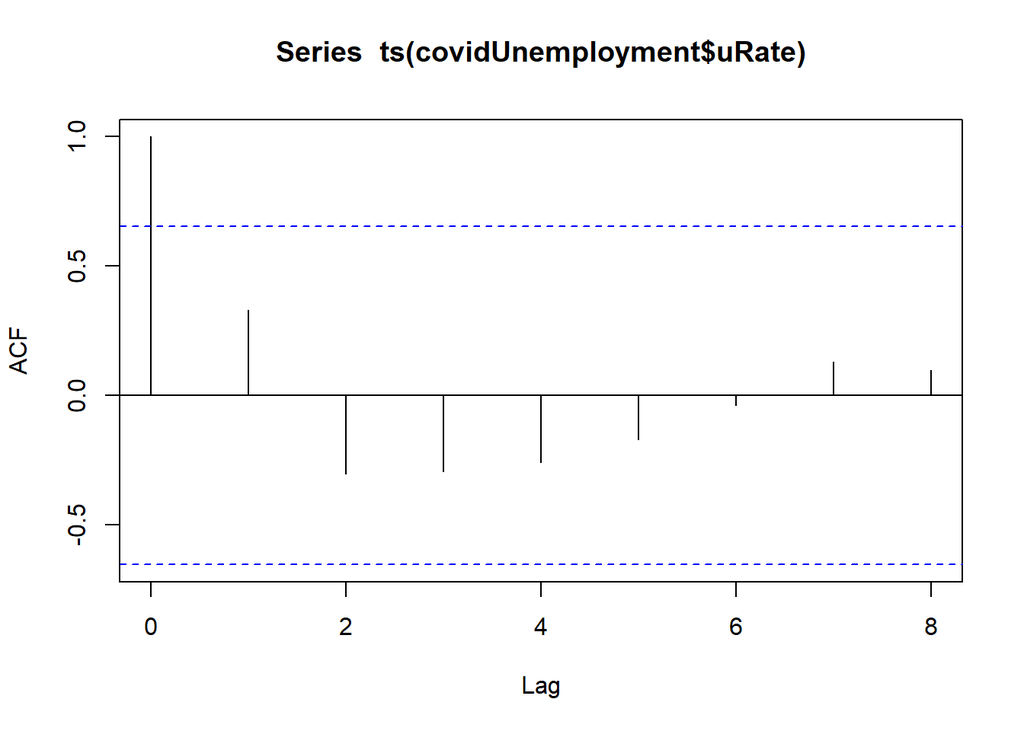

```r
acf(ts(covidUnemployment$uRate))
```

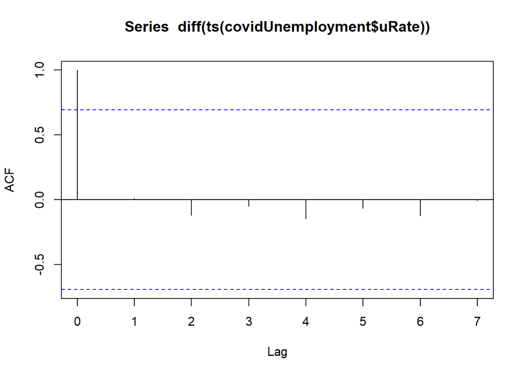

```r
acf(diff(ts(covidUnemployment$uRate)))
```

The residuals for unemployment rate do not show evidence of significant autocorrelation. This justifies fitting a regression model using ordinary least squares instead of generalized least squares.

# Regression: Ordinary Least Squares

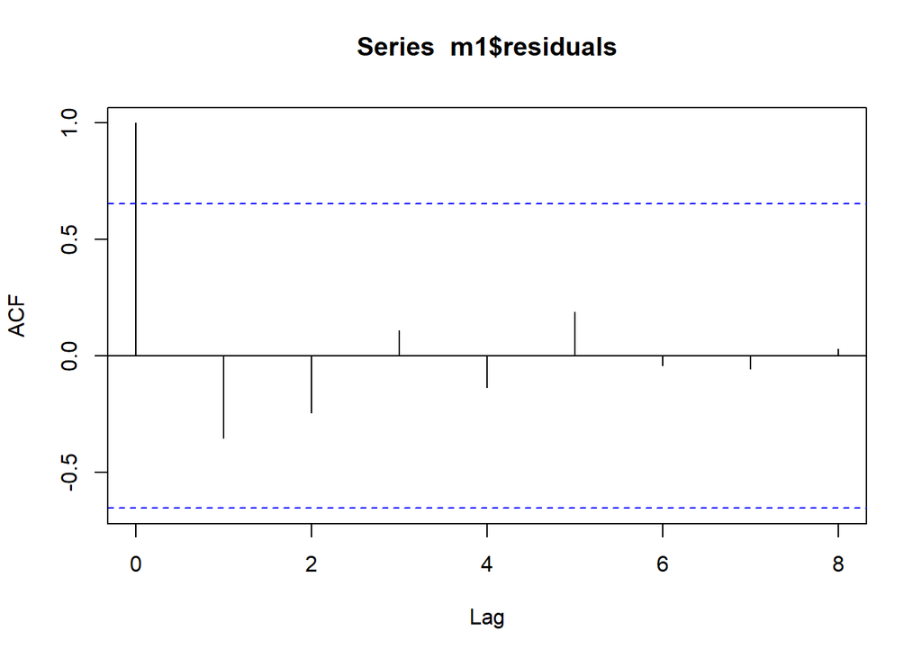

```r
# Full model that includes all features in the data set
m1 = lm(uRate ~ month + newCase + totCase + newDeath + totDeath,
        data = covidUnemployment)

# Check for autocorrelation
acf(m1$residuals)
```

```r
summary(m1)
```

```
##
## Call:
## lm(formula = uRate ~ month + newCase + totCase + newDeath + totDeath,
##     data = covidUnemployment)
##
## Residuals:
##        1        2        3        4        5        6        7        8
##  0.22883 -0.53215  0.62423 -0.44979  0.70710  0.04353 -1.42484  0.28862
##        9
##  0.51446
##
## Coefficients:
##               Estimate Std. Error t value Pr(>|t|)
## (Intercept)  2.016e+00  2.585e+00   0.780   0.4923
## month        1.255e+00  1.692e+00   0.742   0.5121
## newCase      7.768e-07  1.322e-06   0.588   0.5981
## totCase     -1.792e-06  7.385e-07  -2.427   0.0936 .
## newDeath     2.090e-04  4.216e-05   4.957   0.0158 *
## totDeath     1.246e-05  5.526e-05   0.225   0.8361
## ---
## Signif. codes:  0 '***' 0.001 '**' 0.01 '*' 0.05 '.' 0.1 ' ' 1
##
## Residual standard error: 1.127 on 3 degrees of freedom
## Multiple R-squared:  0.9667, Adjusted R-squared:  0.9111
## F-statistic: 17.39 on 5 and 3 DF,  p-value: 0.02006
```

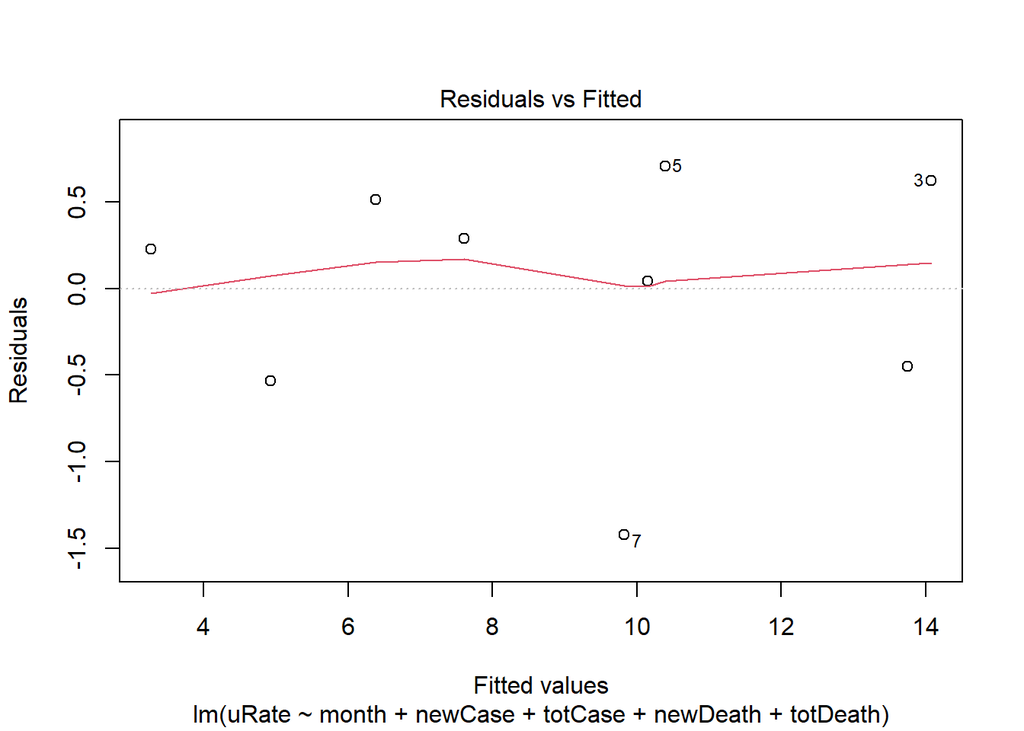

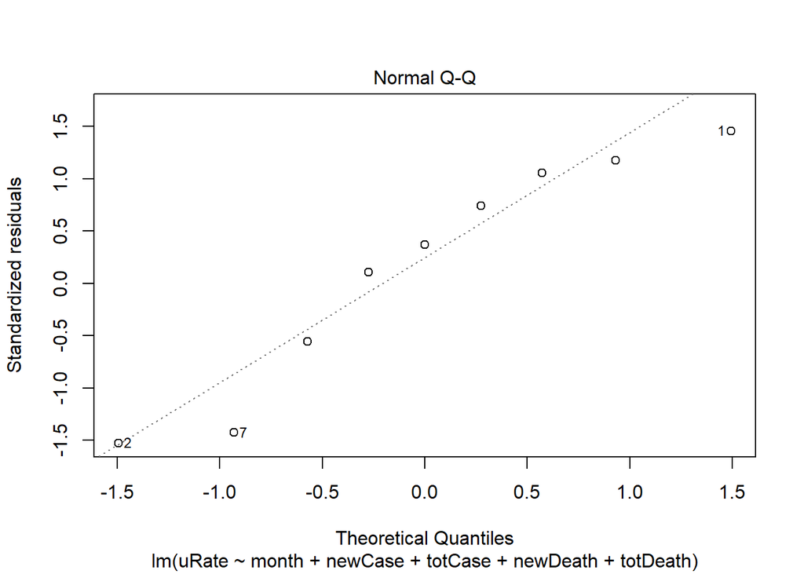

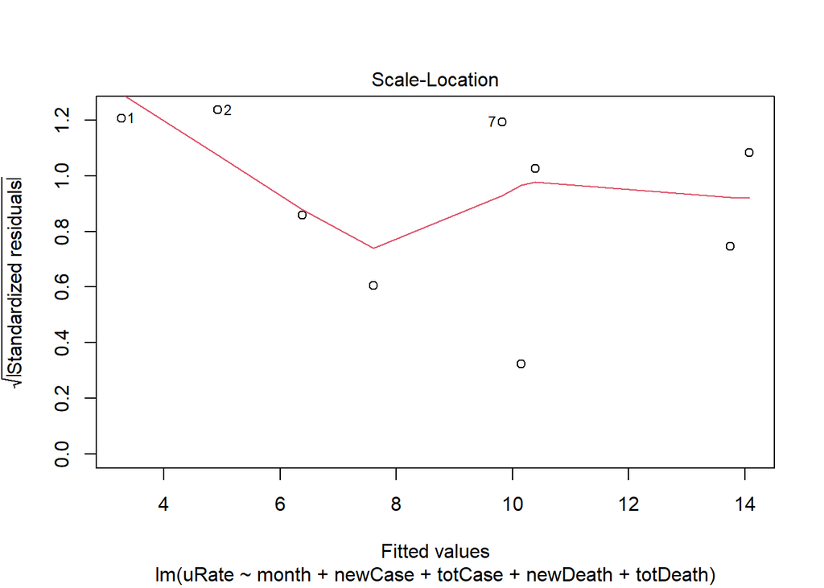

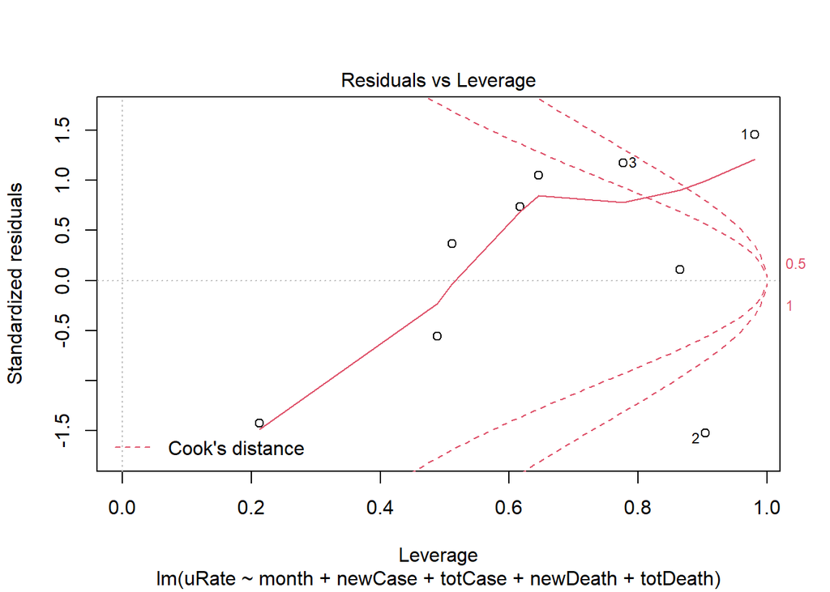

```r
# Residual plots
plot(m1)
```

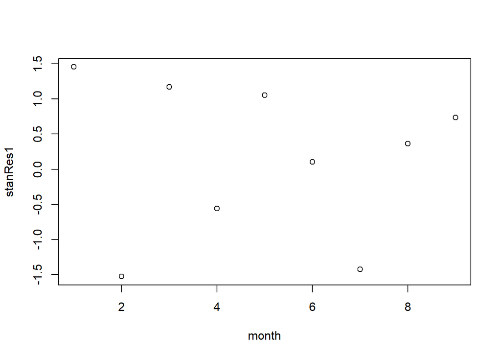

```r
stanRes1 = rstandard(m1)
plot(month,    stanRes1)
```

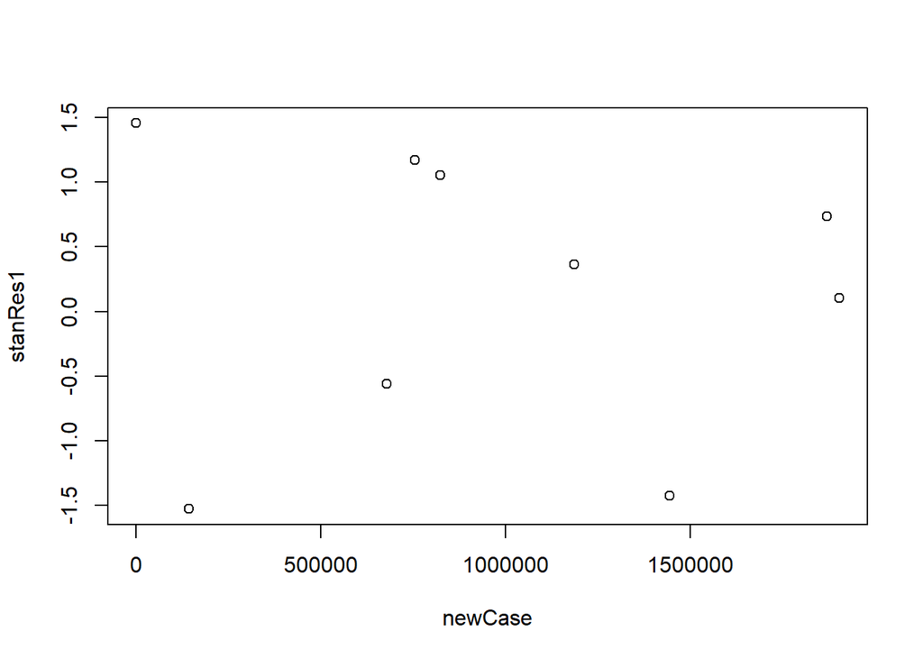

```r
plot(newCase,  stanRes1)
```

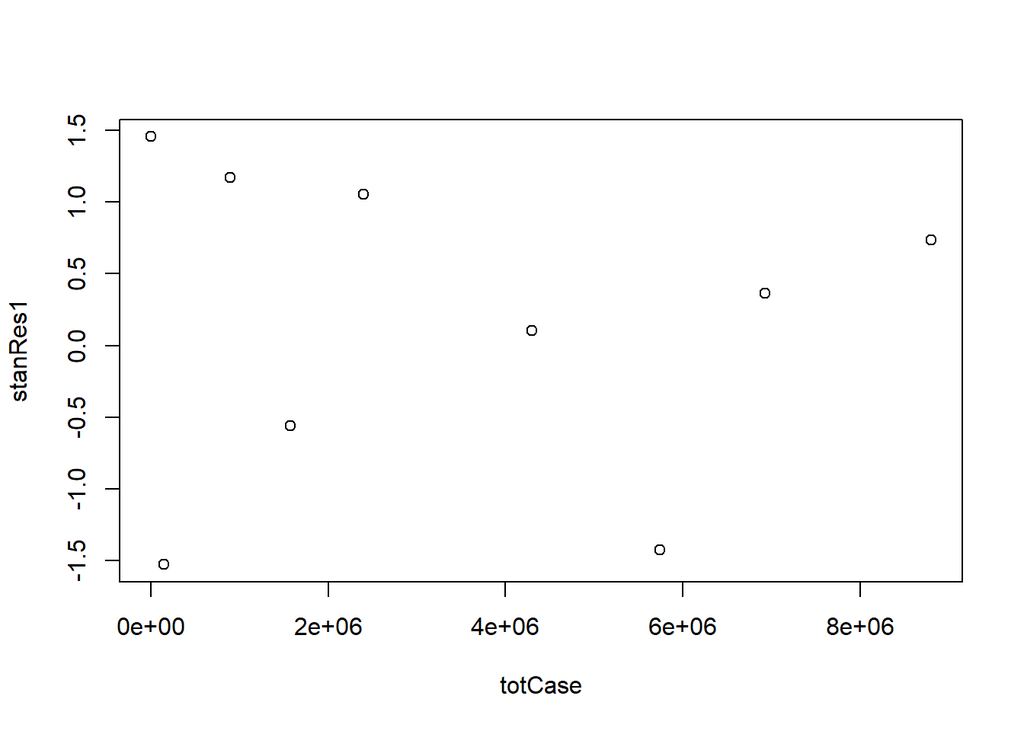

```r
plot(totCase,  stanRes1)
```

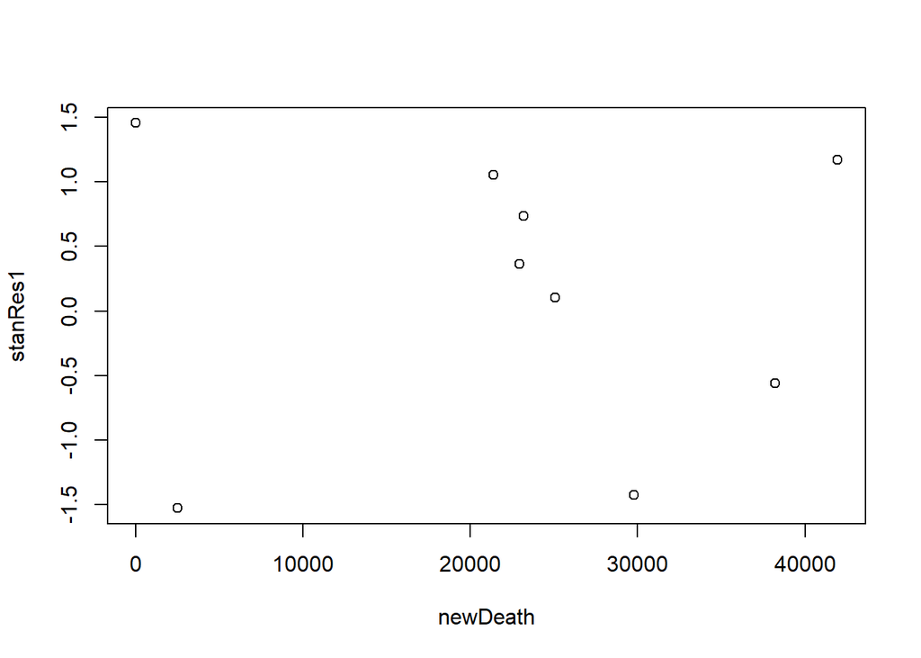

```r
plot(newDeath, stanRes1)
```

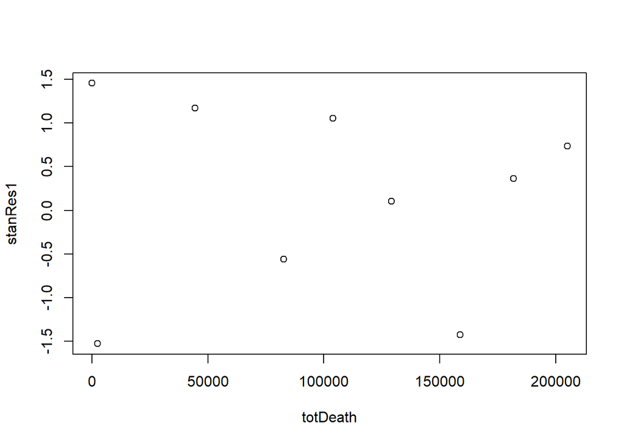

```r
plot(totDeath, stanRes1)
```

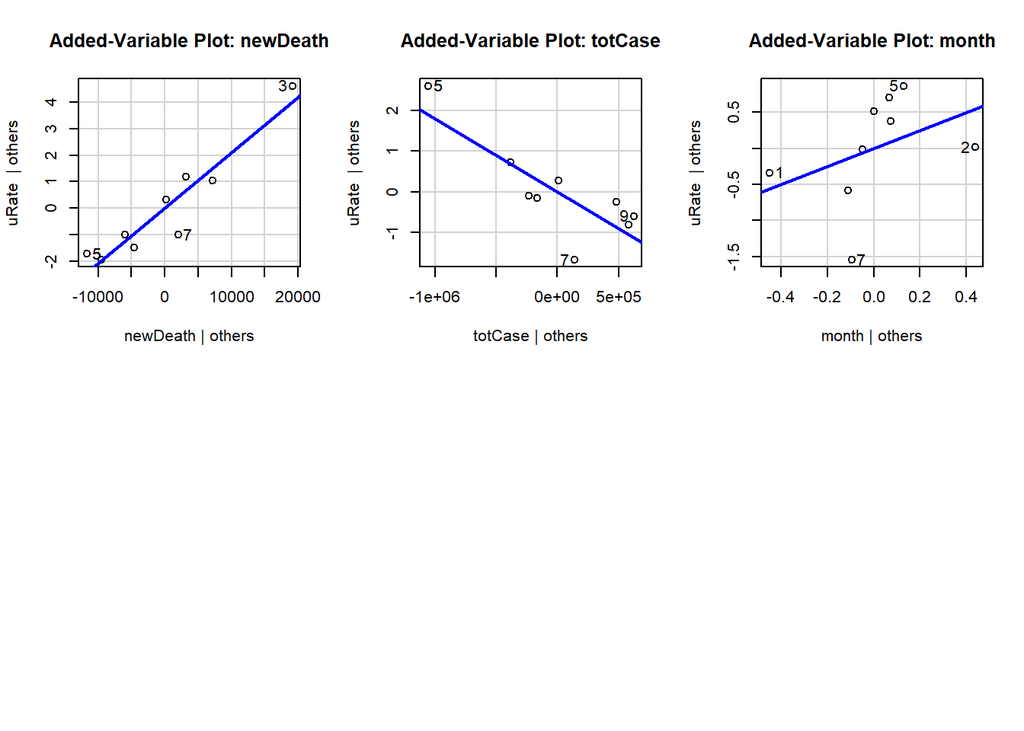

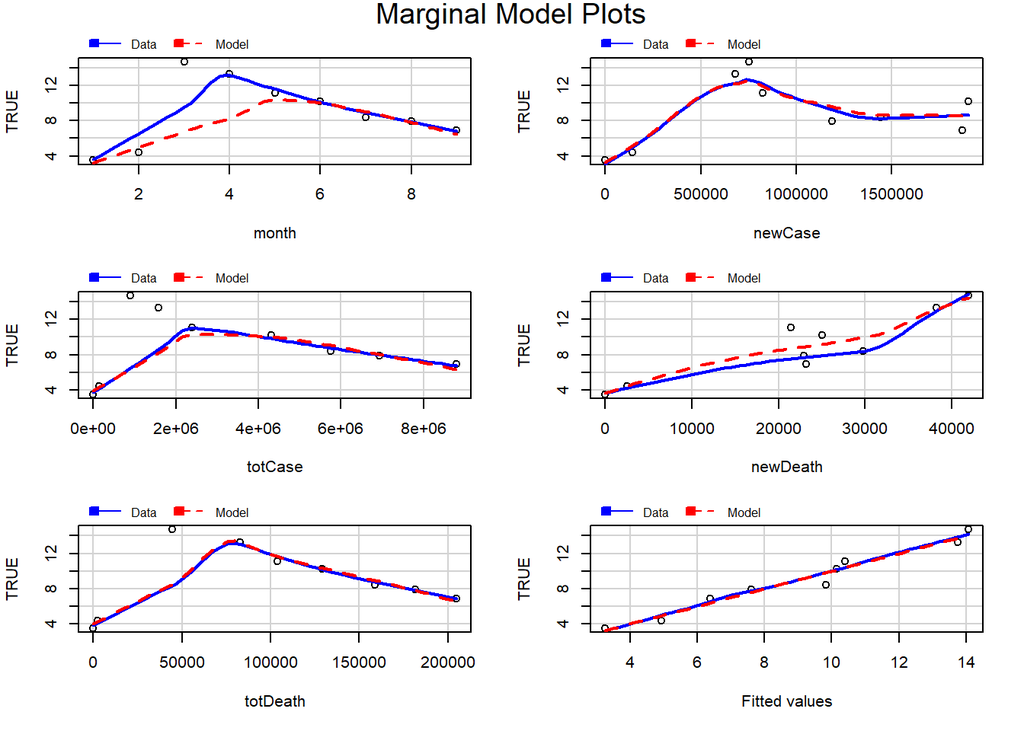

```r
# Added variable plots
library(car)
par(mfrow=c(2,3))
avPlot(m1,variable="newDeath",ask=FALSE)
avPlot(m1,variable="totCase",ask=FALSE)
avPlot(m1,variable="month",ask=FALSE)

# Marginal model plots
mmps(m1)
```

Using the autocorrelation function, the plot of residuals for the full model does not show evidence of sigificant autocorrelation.

The first two values in the data set, corresponding to February and March, are bad leverage points. During these months, the SARS-CoV-2 virus had not yet completed its initial spread across the United States.

For the month of February, the national unemployment rate was at a 50-year low of 3.5%. For COVID-19, there were 19 cases and 1 death. These low figures compared to subsequent months, explains why February is a bad leverage point.

The national unemployment rate increased to 4.4% in March, then to 14.7% in April. The number of COVID-19 cases and deaths followed a similar trajectory for these two months. These sharp increases from March to April, explain why March was the other bad leverage point.

The overall F-test for the full model is statistically significant, with a p-value less than 0.05. However, only one of the estimated regression coefficients is statistically significant. This is the number of new deaths, with a p-value less than 0.05. This is also evident in the marginal model plots. Thus, the next step was to choose a subset of the predictors using variable selection.

# Variable selection using all possible subsets

```r
#install.packages("leaps")
library(leaps)
```

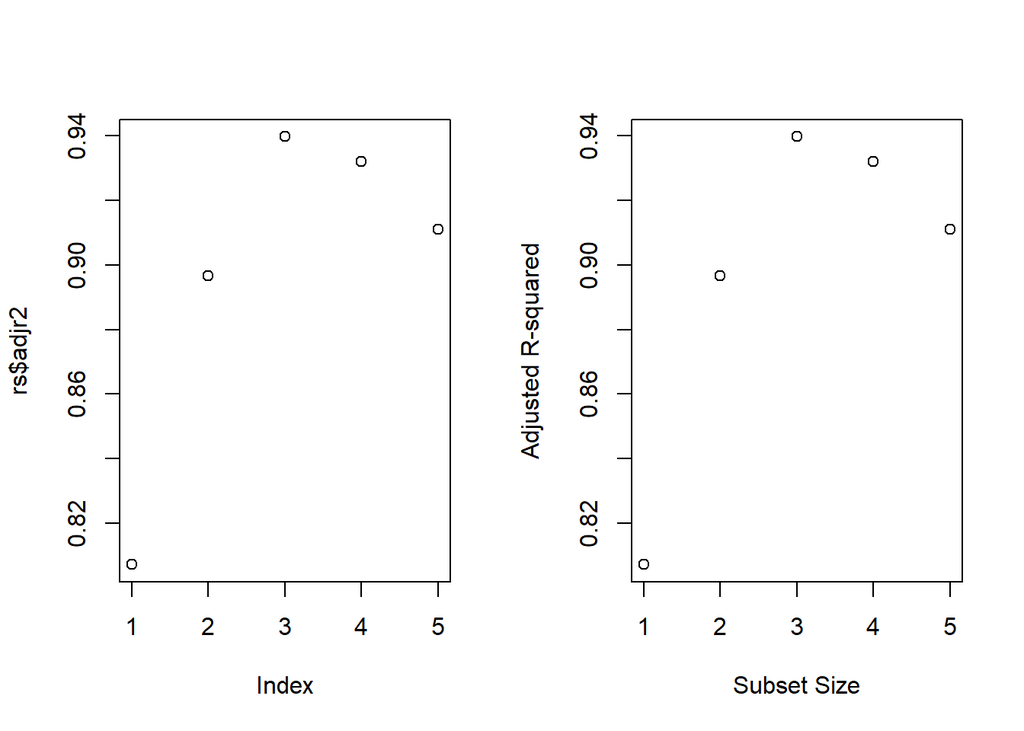

```r
b    = regsubsets(as.matrix(covidMonthly), uRate)
rs   = summary(b)
adjRsq = rs$adjr2

# Plots of adjusted R-squared against the number of predictors
par(mfrow=c(1,2))
plot(rs$adjr2)
plot(1:5,rs$adjr2,xlab="Subset Size",ylab="Adjusted R-squared")
```

```r
library(car)
#subsets(b,statistic=c("adjr2"))

# Calculate adjusted R-squared
om1  = lm(uRate ~ newDeath)
om2  = lm(uRate ~ newDeath + totCase)
om3  = lm(uRate ~ newDeath + totCase + month)
om4  = lm(uRate ~ newDeath + totCase + month + newCase)
om5  = m1

# Subset size = 1
n        = length(om1$residuals)
npar     = length(om1$coefficients) + 1
sub1AIC  = (extractAIC(om1,k=2))[2]
sub1AICc = (extractAIC(om1,k=2) + 2*npar*(npar+1)/(n-npar-1))[2]
sub1BIC  = (extractAIC(om1,k=log(n)))[2]

# Subset size = 2
npar     = length(om2$coefficients) + 1
sub2AIC  = (extractAIC(om2,k=2))[2]
sub2AICc = (extractAIC(om2,k=2) + 2*npar*(npar+1)/(n-npar-1))[2]
sub2BIC  = (extractAIC(om2,k=log(n)))[2]

# Subset size = 3
npar     = length(om3$coefficients) +1
sub3AIC  = (extractAIC(om3,k=2))[2]
sub3AICc = (extractAIC(om3,k=2) + 2*npar*(npar+1)/(n-npar-1))[2]
sub3BIC  = (extractAIC(om3,k=log(n)))[2]

# Subset size = 4
npar     = length(om4$coefficients) +1
sub4AIC  = (extractAIC(om4,k=2))[2]
sub4AICc = (extractAIC(om4,k=2) + 2*npar*(npar+1)/(n-npar-1))[2]
sub4BIC  = (extractAIC(om4,k=log(n)))[2]

# Subset size = 5
npar     = length(om5$coefficients) +1
sub5AIC  = (extractAIC(om5,k=2))[2]
sub5AICc = (extractAIC(om5,k=2) + 2*npar*(npar+1)/(n-npar-1))[2]
sub5BIC  = (extractAIC(om5,k=log(n)))[2]

# Table with four criteria for evaluating subsets of predictors
AIC   = c(sub1AIC, sub2AIC, sub3AIC, sub4AIC, sub5AIC)
AICc  = c(sub1AICc, sub2AICc, sub3AICc, sub4AICc, sub5AICc)
BIC   = c(sub1BIC, sub2BIC, sub3BIC, sub4BIC, sub5BIC)
SubSize = 1:5
cbind(SubSize, adjRsq, AIC, AICc, BIC)
```

```
##      SubSize    adjRsq       AIC      AICc       BIC
## [1,]       1 0.8070927 10.853273  15.65327 11.247722
## [2,]       2 0.8967661  5.839004  15.83900  6.430678
## [3,]       3 0.9397833  1.346686  21.34669  2.135585
## [4,]       4 0.9321760  2.409091  44.40909  3.395214
## [5,]       5 0.9110751  4.257834 116.25783  5.441181
```

# Linear model using best subset

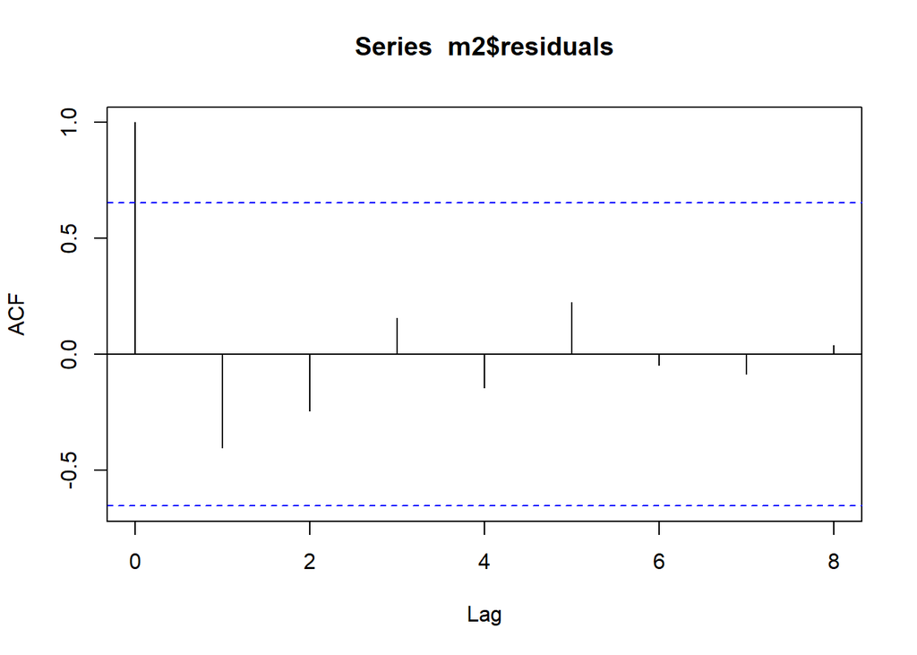

```r
# Preferred three-variable model
m2 = om3

# Check for autocorrelation
acf(m2$residuals)
```

```r
summary(m2)
```

```
##
## Call:
## lm(formula = uRate ~ newDeath + totCase + month)
##
## Residuals:
##        1        2        3        4        5        6        7        8
##  0.34393 -0.73392  0.54333 -0.53856  0.69834  0.61298 -1.39649 -0.02054
##        9
##  0.49092
##
## Coefficients:
##               Estimate Std. Error t value Pr(>|t|)
## (Intercept)  1.476e+00  1.339e+00   1.102 0.320613
## newDeath     2.193e-04  3.122e-05   7.024 0.000903 ***
## totCase     -1.735e-06  6.027e-07  -2.879 0.034621 *
## month        1.680e+00  7.307e-01   2.299 0.069844 .
## ---
## Signif. codes:  0 '***' 0.001 '**' 0.01 '*' 0.05 '.' 0.1 ' ' 1
##
## Residual standard error: 0.9271 on 5 degrees of freedom
## Multiple R-squared:  0.9624, Adjusted R-squared:  0.9398
## F-statistic: 42.62 on 3 and 5 DF,  p-value: 0.0005522
```

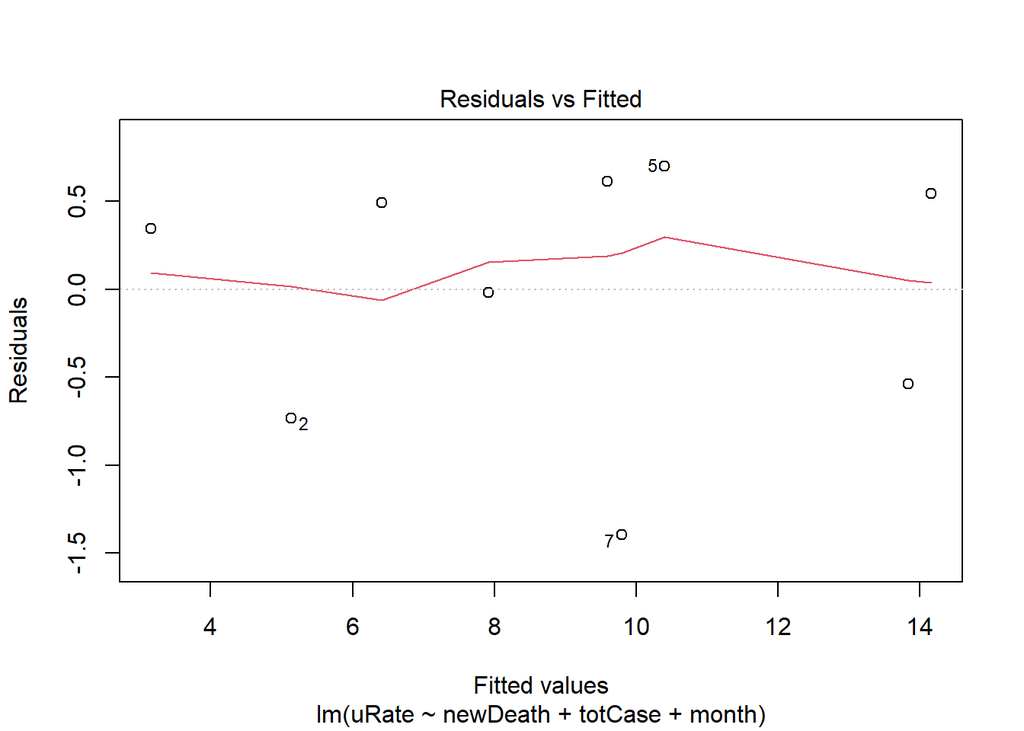

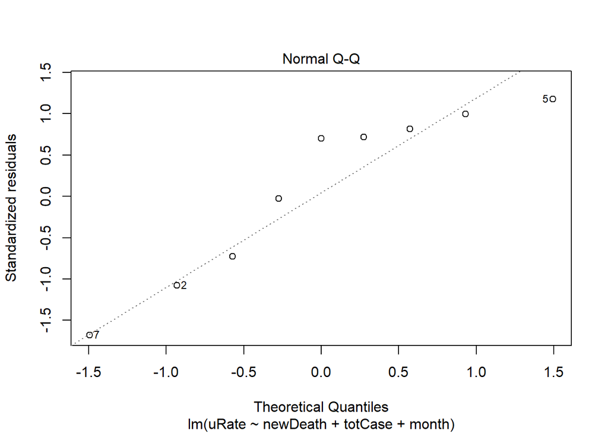

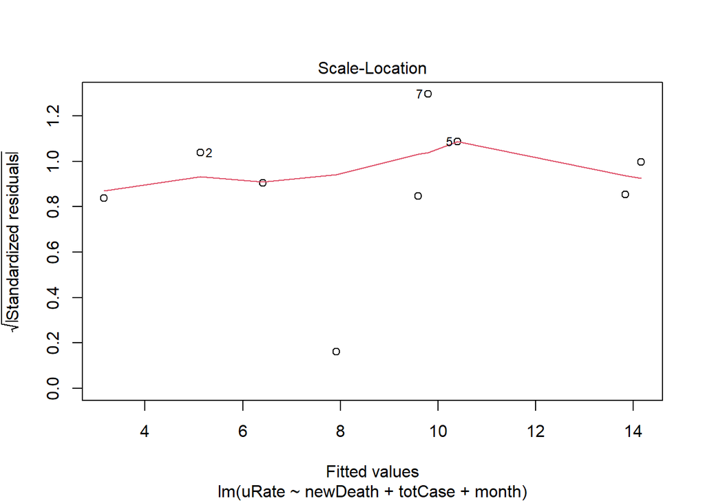

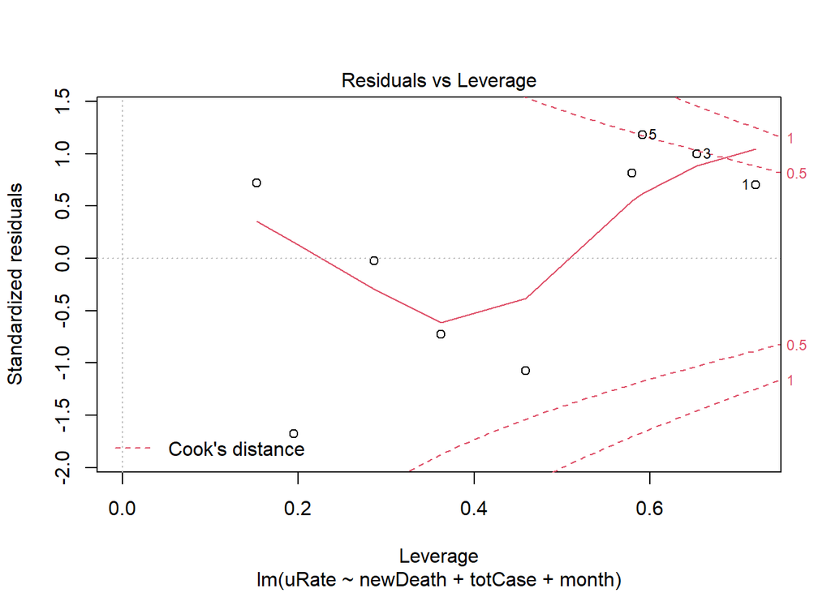

```r
# Residual plots
plot(m2)
```

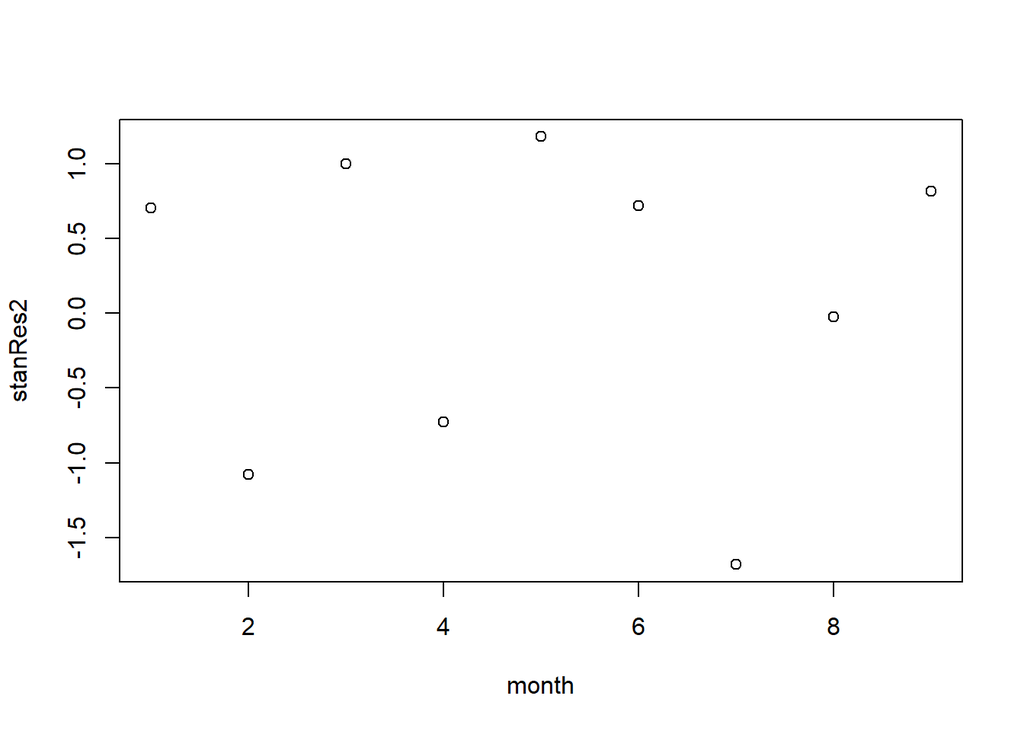

```r
stanRes2 = rstandard(m2)
plot(month,    stanRes2)
```

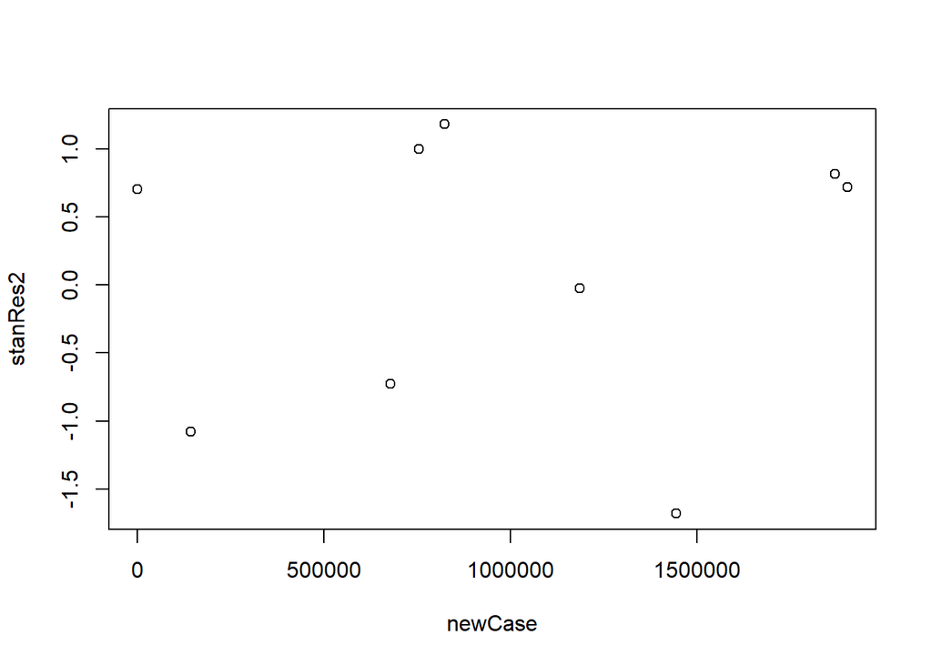

```r
plot(newCase,  stanRes2)
```

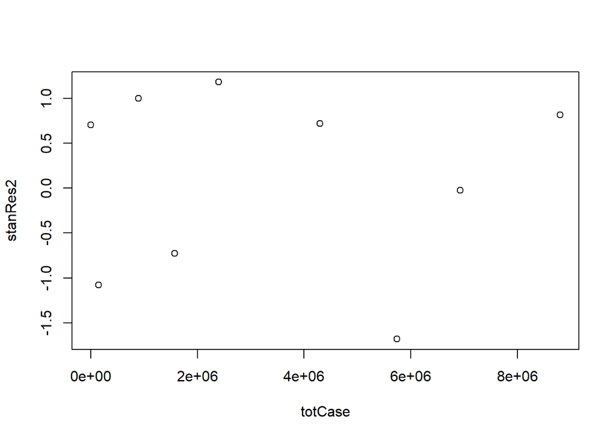

```r
plot(totCase,  stanRes2)
```

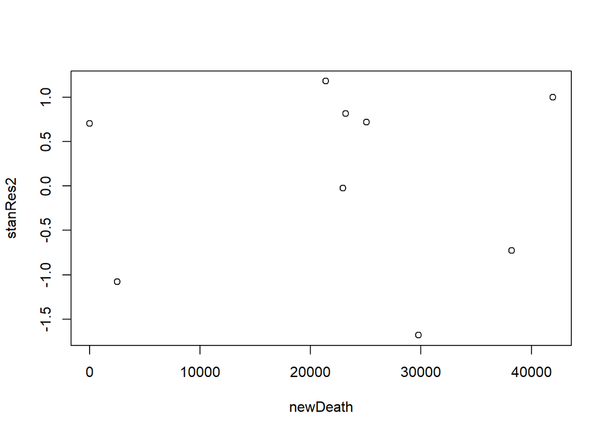

```r
plot(newDeath, stanRes2)
```

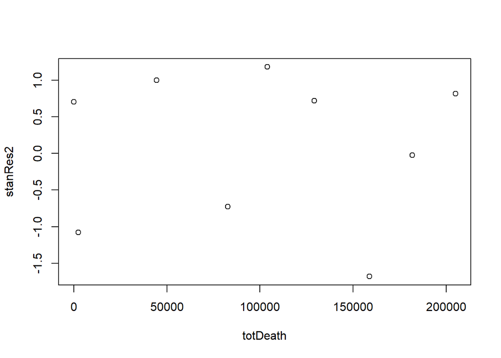

```r
plot(totDeath, stanRes2)
```

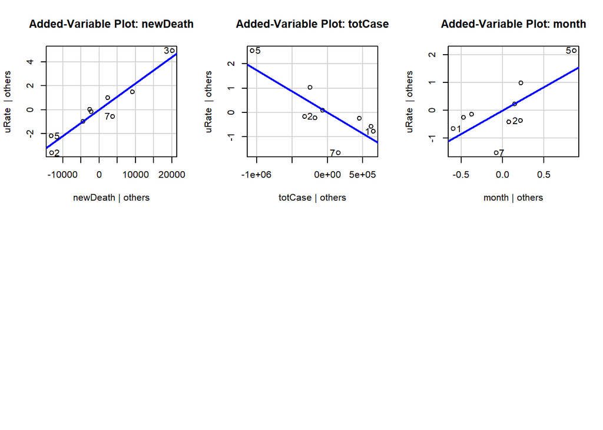

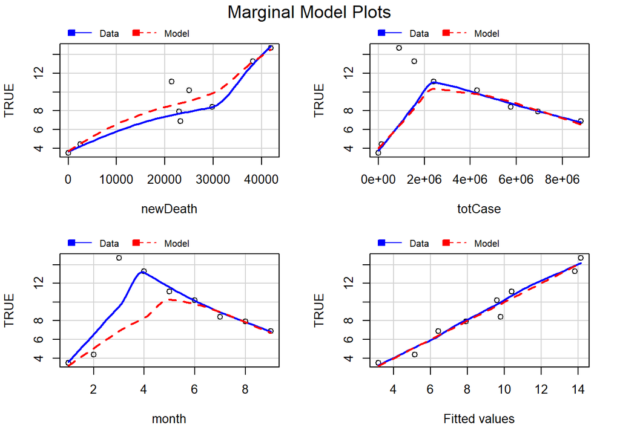

```r
# Added variable plots
library(car)
par(mfrow=c(2,3))
avPlot(m2,variable="newDeath",ask=FALSE)
avPlot(m2,variable="totCase",ask=FALSE)
avPlot(m2,variable="month",ask=FALSE)

# Marginal model plots
mmps(m2)
```

Using the autocorrelation function, the plot of residuals for the chosen three-variable model does not show evidence of sigificant autocorrelation.

The plot of residuals versus fitted values does not show evidence of nonconstant variance, suggesting that the model is a valid fit for the data. The normal Q-Q plot suggests that a straight-line regression fit is appropriate due to the lack of bad leverage points. The plot of the square root of the absolute value of the standardized residuals against fitted values shows evidence of constant variance due to the mostly horizontal loess fit.

In the plot of Residuals vs. Leverage, none of the standardized residuals exceed a Cook’s distance of 1. However, the value for time 5 warrants investigation because its residual slightly exceeds a Cook’s distance of 0.5.

The marginal model plots show that the fitted values match well with the curvature of the nonparametric estimates.

Altogether, the diagnostic plots suggest that the three-variable model provides a valid fit for the data, and a better fit than the full model.

# Prediction interval for November 2020

```r
bestOut = predict(m2, interval = "prediction",
                  newdata = data.frame(newDeath = newDeath[9],
                                       totCase = totCase[9],
                                       month = 10))
bestOut
```

```
##        fit      lwr      upr
## 1 8.089205 4.954087 11.22432
```